# Midterm Survival Problem Solutions

Dr. Levkoff

March 23, 2019

```r
##loading necessary libraries###
library(ggplot2)  ##for graphing in problem #9
library(plyr)  ##for manipulating data
set.seed(1234) ##setting seed for simulation problems
```

### Problem 1

Paste the file’s filepath (not the folder’s) into the read.csv function to download the dataset and store it per the instructions:

```r
NHIS<-read.csv('C:/Users/Steve/Desktop/ECON386SP19/NHIS_RAW.csv')  ##the filepath will be different on your machine - copy and paste it into the single quotes to replicate
##View(NHIS)
```

Part a): We can look at some summary statistics and empirical distribution (histograms) for the key variables of interest:

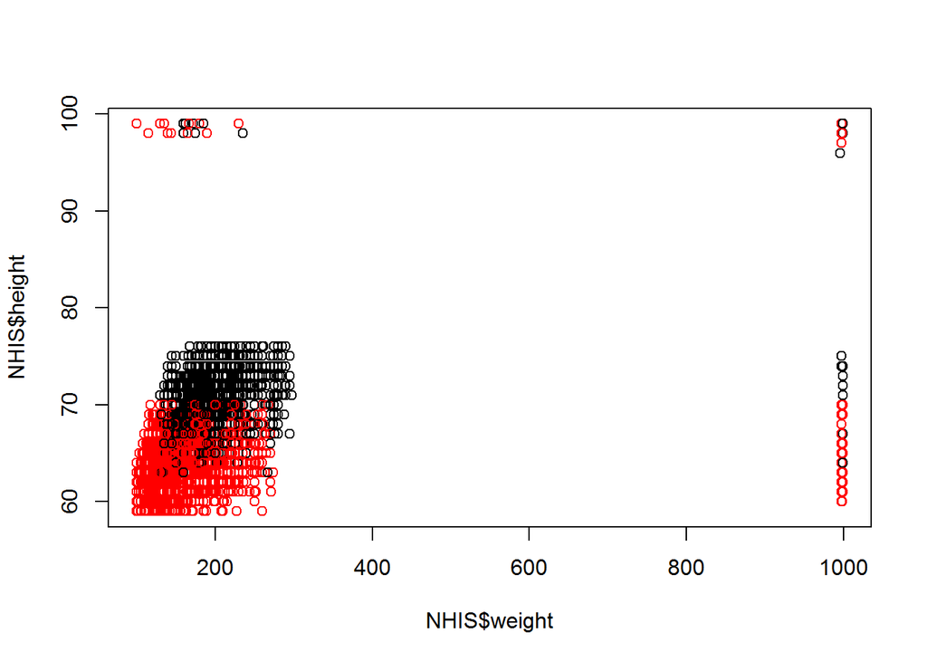

```r
plot(NHIS$weight, NHIS$height, col=factor(NHIS$SEX))  ##plot of weight vs height colored by the sex variable
```

Note that there appears to be outlier data (weight near 1000lbs and heights near 100 inches). Looking at some summary statistics:

```r
summary(NHIS$weight)
```

```
##    Min. 1st Qu.  Median    Mean 3rd Qu.    Max.
##   100.0   149.0   175.0   266.2   215.0   999.0
```

```r
summary(NHIS$height)
```

```
##    Min. 1st Qu.  Median    Mean 3rd Qu.    Max.
##   59.00   64.00   67.00   69.58   71.00   99.00
```

We can see that the maximum values are skewing the data since the mean is much larger than the median. A similar analysis of the SLEEP variable will reveal infeasible survey responses (you can’t sleep more than 24 hours in a day).

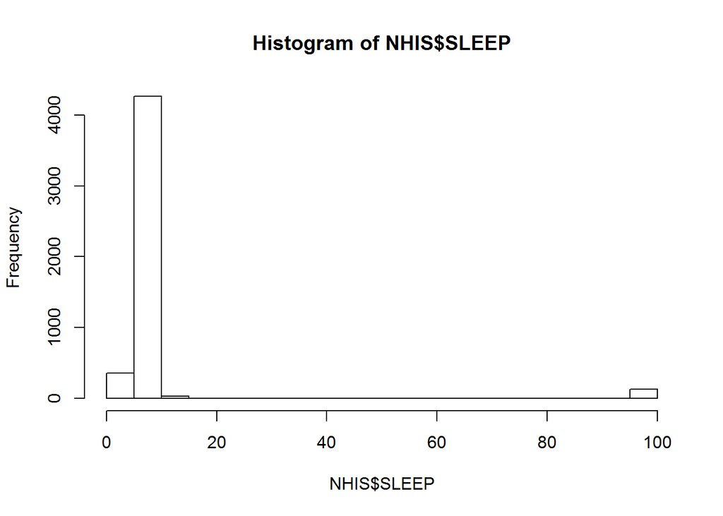

```r
hist(NHIS$SLEEP)
```

```r
summary(NHIS$SLEEP)
```

```
##    Min. 1st Qu.  Median    Mean 3rd Qu.    Max.
##   3.000   6.000   7.000   9.507   8.000  99.000
```

There also appears to be outliers in the educ (years of reported educational attainment).

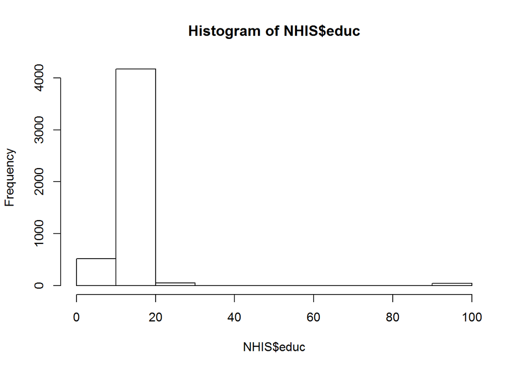

```r
hist(NHIS$educ)
```

```r
summary(NHIS$educ)
```

```
##    Min. 1st Qu.  Median    Mean 3rd Qu.    Max.
##    0.00   12.00   13.00   14.25   16.00   99.00
```

as well as the BMI (body mass index) variable:

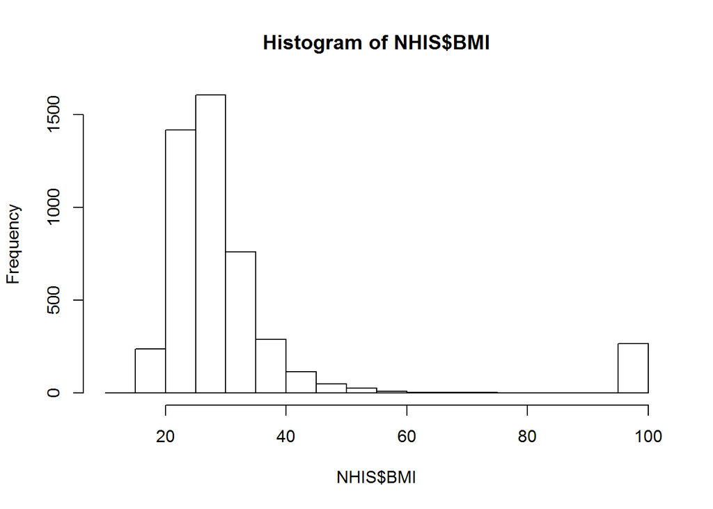

```r
hist(NHIS$BMI)
```

```r
summary(NHIS$BMI)
```

```
##    Min. 1st Qu.  Median    Mean 3rd Qu.    Max.
##   12.91   23.63   26.97   31.73   31.51   99.99
```

Note that the dimensionality of the data is

```r
##part b)
dim(NHIS)
```

```
## [1] 4785    9
```

We will keep track of this as we trim observations from the set of outliers, which in some cases, will result in lost information - so there is a tradeoff when cleaning that must be negotiated.

Here we entertain two methodologies for cleaning data: 1) deletion; vs. 2) deletetion only when necessary. The latter method results in less lost information from trimming outlier data.

```r
##part c)
NHIS_1<-subset(NHIS, SLEEP<=24) ##deletes observations with invalid sleep response
dim(NHIS_1)  ##dimensions of the data after 1st step
```

```
## [1] 4657    9
```

```r
(dim(NHIS)[1]-dim(NHIS_1)[1])/dim(NHIS)[1]  ##computes fraction of data lost in first step of cleaning
```

```
## [1] 0.02675026
```

Note that we lost about 2% of the observations from removing the outliers on the SLEEP variable. Cleaning up the remainder in sequence per the instructions:

```r
##part d)
NHIS_2<-subset(NHIS_1, height<90)
dim(NHIS_2)  ##dimensions of the data after 2nd step
```

```
## [1] 4323    9
```

```r
NHIS_3<-subset(NHIS_2, weight<450)
dim(NHIS_3)  ##dimensions of the data after 3rd step
```

```
## [1] 4211    9
```

```r
NHIS_4<-subset(NHIS_3, BMI<60)
dim(NHIS_4)  ##dimensions of the data after 4th step
```

```
## [1] 4211    9
```

```r
NHIS_5<-subset(NHIS_4, educ<35)
dim(NHIS_5)  ##dimensions of the data after 5th step
```

```
## [1] 4189    9
```

Alternatively, we could have done all of the steps at once:

```r
##part e)
NHIS_A<-subset(NHIS, SLEEP<=24 & BMI<60 & educ<35 & height<90 & weight<450)
```

Comparing the dimensionality of the cleaned data to the raw data

```r
##part f)
dim(NHIS_A)
```

```
## [1] 4189    9
```

```r
(dim(NHIS)[1]-dim(NHIS_A)[1])/dim(NHIS)[1]  ##percentage of total observations lost from trimming outliers
```

```
## [1] 0.1245559
```

we have lost about 12% of the total observations from outlier removal (deletion).

Removing uninteresting columns:

```r
##part g)
NHIS_A$HHX<-NULL  ##removes this column variable
NHIS_A$FPX<-NULL  ##removes this column variable
NHIS_A$FMX<-NULL  ##removes this column variable
dim(NHIS_A)
```

```
## [1] 4189    6
```

Now we apply the second method of outlier removal: deletion when necessary.

```r
##part h) assign NA to invalid SLEEP responses
NHIS_B<-NHIS
NHIS_B$SLEEP[NHIS_B$SLEEP>24]<-NA
##part i)  assigns NA to the invalid/outlier responses
NHIS_B$height[NHIS_B$height>90]<-NA
NHIS_B$weight[NHIS_B$weight>450]<-NA
NHIS_B$BMI[NHIS_B$BMI>60]<-NA
NHIS_B$educ[NHIS_B$educ>35]<-NA
dim(NHIS_B)  ##no data lost - same as dim(NHIS)
```

```
## [1] 4785    9
```

```r
##View(NHIS_B)
```

After running the View() function, we can observe that there are several “NA” values in place of where outlier values used to be. If we try to compute a summary statistic:

```r
##part j)
mean(NHIS_B$SLEEP) ##there was a slight typ here in the problem set instrucitons - no variable was defined
```

```
## [1] NA
```

```r
mean(NHIS_B$SLEEP, na.rm=TRUE) ##tells R to ignore the NA
```

```
## [1] 7.073008
```

R will not be able to unless we tell it to ignore cases where there is an NA and to use only the other relevant information, resulting in minimal information loss.

### Problem 2

```r
##parts a)-b)
power_plants<-read.table('C:/Users/Steve/Desktop/ECON386SP19/power_plants.txt', header = TRUE)  ##the filepath will be different on your machine - copy and paste it into the single quotes to replicate
##View(power_plants)
dim(power_plants)
```

```
## [1] 1012   15
```

The dataset appears to be a panel data set of 92 power plants over an 11 year period.

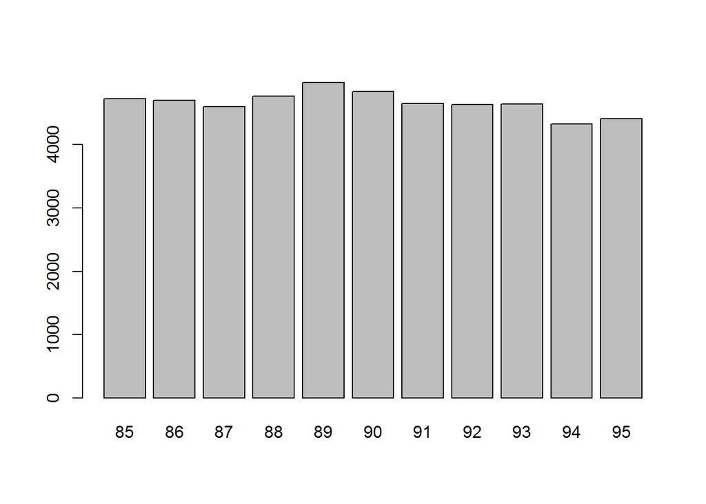

```r
##part c)
NOXTotByYear<-aggregate(NOX ~ Year, power_plants, sum)  ##sums NOX emissions across plants within each year
barplot(NOXTotByYear$NOX, names.arg = as.character(NOXTotByYear$Year))
```

```r
NOXTotByYear  ##reports summarized dataset
```

```
##    Year      NOX
## 1    85 4727.872
## 2    86 4704.083
## 3    87 4597.896
## 4    88 4769.211
## 5    89 4982.996
## 6    90 4837.722
## 7    91 4649.429
## 8    92 4636.815
## 9    93 4642.269
## 10   94 4330.130
## 11   95 4409.451
```

From the summarized table on aggregated emissions, we see that the emissions were the highest in ’89 and the lowest (in the dataset) in ’94.

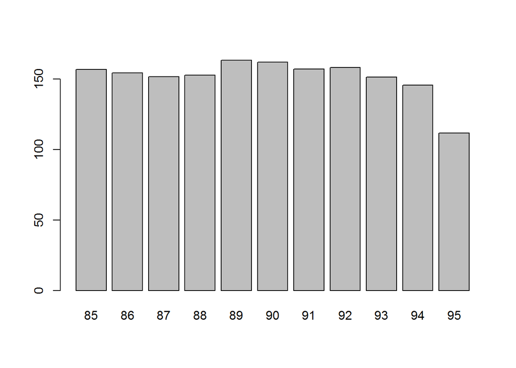

```r
##part d)
SO2AvgByYear<-aggregate(SO2 ~ Year, power_plants, mean)  ##averages SO2 emissions across plants within each year
barplot(SO2AvgByYear$SO2, names.arg = as.character(SO2AvgByYear$Year))
```

```r
SO2AvgByYear  ##reports summarized dataset
```

```
##    Year      SO2
## 1    85 156.8064
## 2    86 154.3504
## 3    87 151.4722
## 4    88 152.6857
## 5    89 163.2529
## 6    90 161.7448
## 7    91 157.1087
## 8    92 158.1607
## 9    93 151.1840
## 10   94 145.6782
## 11   95 111.6307
```

From the table that we have constructed, it seems that the largest reduction in SO2 emissions took place between ’94-’95.

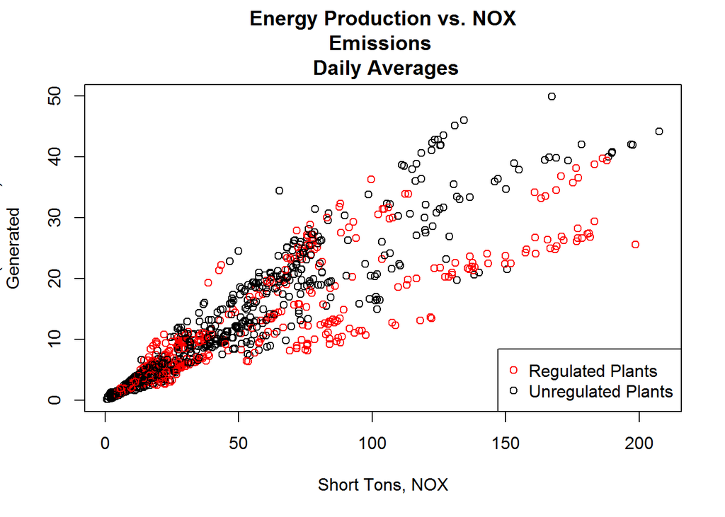

```r
##part e) small typo here - the code for this part should reference NOX, not SO2 - we take care of SO2 in part g)
plot(power_plants$NOX, power_plants$Energy, main = "Energy Production vs. NOX
Emissions \n Daily Averages", xlab = "Short Tons, NOX", ylab = "Mwh (thousands)
Generated", col = power_plants$PhaseI+1)
legend("bottomright", legend=c('Regulated Plants', 'Unregulated Plants'), pch = c(1,1),
col = c(2,1))
```

Part f): By observing the plot generated above, it seems like the regulated plants seem to (on average) generate more NOX for any given level of energy production. Can you add a regression line for each group (red and black) to verify the difference in the slopes?

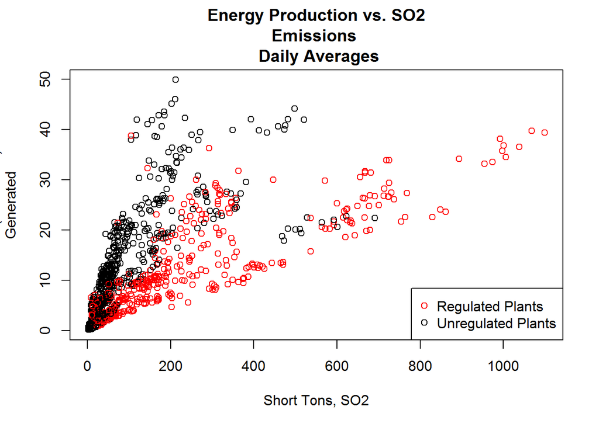

```r
##part g)
plot(power_plants$SO2, power_plants$Energy, main = "Energy Production vs. SO2
Emissions \n Daily Averages", xlab = "Short Tons, SO2", ylab = "Mwh (thousands)
Generated", col = power_plants$PhaseI+1)
legend("bottomright", legend=c('Regulated Plants', 'Unregulated Plants'), pch = c(1,1),
col = c(2,1))
```

The plot of energy production against S02 emissions seems to reveal a smilar, albeit more obvious pattern - the plants that were chosen to face regulations were generating more pollutant on average at any level of electrical generation.

### Problem 3

We will now use the power_plants.txt dataset to build some linear regression models.

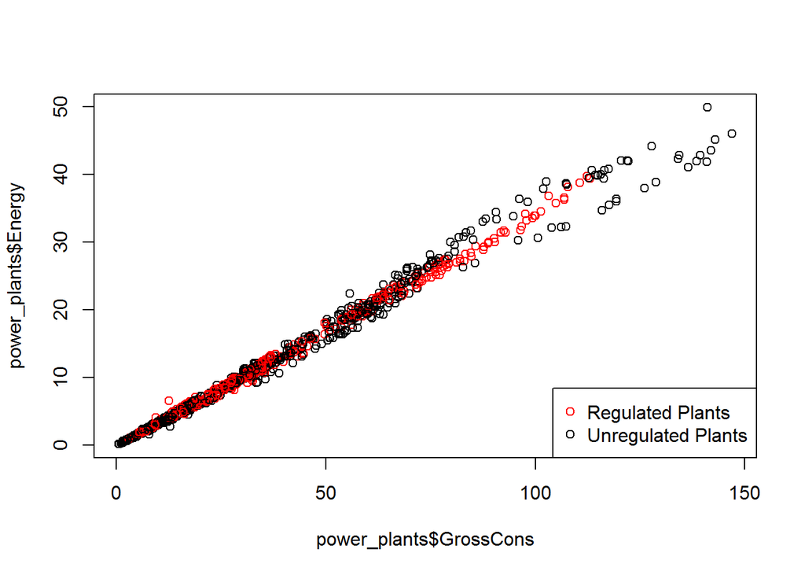

```r
##part a)
plot(power_plants$GrossCons, power_plants$Energy, col=factor(power_plants$PhaseI))
legend("bottomright", legend=c('Regulated Plants', 'Unregulated Plants'), pch = c(1,1), col = c(2,1))
```

By observing the diagram above, there seems to be a strong linear relationship between energy output and gross energy consumption. The slope of the plot looks to be close to 1/3, but we will have to verify with a linear model:

```r
##part b)
M1<-lm(Energy ~ GrossCons, power_plants)
summary(M1)
```

```
##
## Call:
## lm(formula = Energy ~ GrossCons, data = power_plants)
##
## Residuals:
##     Min      1Q  Median      3Q     Max
## -5.8271 -0.3095  0.0132  0.3007  4.2134
##
## Coefficients:
##             Estimate Std. Error t value Pr(>|t|)
## (Intercept) -0.17445    0.04868  -3.583 0.000356 ***
## GrossCons    0.33958    0.00103 329.726  < 2e-16 ***
## ---
## Signif. codes:  0 '***' 0.001 '**' 0.01 '*' 0.05 '.' 0.1 ' ' 1
##
## Residual standard error: 0.9763 on 1010 degrees of freedom
## Multiple R-squared:  0.9908, Adjusted R-squared:  0.9908
## F-statistic: 1.087e+05 on 1 and 1010 DF,  p-value: < 2.2e-16
```

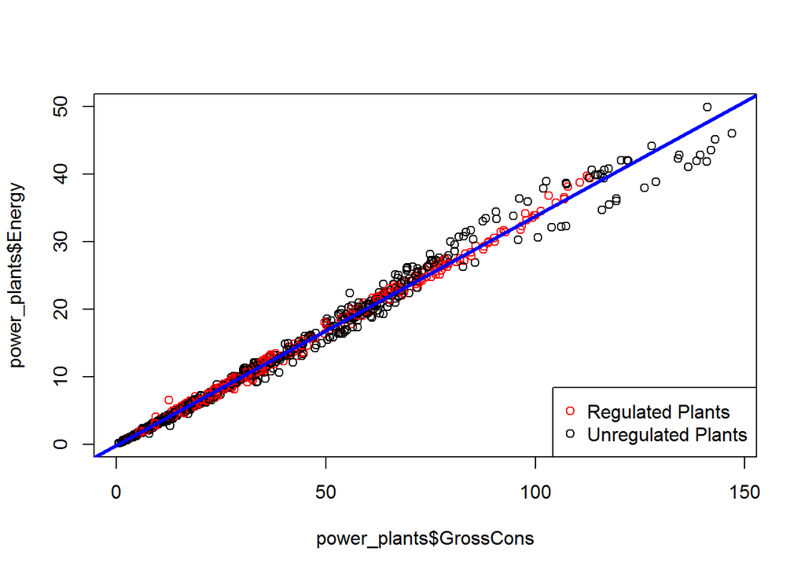

```r
##replotting the diagram with the regression line
plot(power_plants$GrossCons, power_plants$Energy, col=factor(power_plants$PhaseI))
legend("bottomright", legend=c('Regulated Plants', 'Unregulated Plants'), pch = c(1,1), col = c(2,1))
abline(M1, lty=1, col = 4, lwd= 3)  ##adds blue regression line to diagram
```

The coefficient on GrossCons is approximately 1/3 (and it is statistically significant). An additional unit of energy consumed generates only 1/3 of a unit of output, implying that about 2/3 of energy consumption is wasted/ The model explains about 99% of the variation in energy output across firm-years when controlling for gross consumption of energy inputs only.

```r
M1_1<-lm(GrossCons ~ Energy, power_plants)
summary(M1_1)
```

```
##
## Call:
## lm(formula = GrossCons ~ Energy, data = power_plants)
##
## Residuals:
##      Min       1Q   Median       3Q      Max
## -11.6860  -0.9812  -0.1978   0.8370  17.9608
##
## Coefficients:
##             Estimate Std. Error t value Pr(>|t|)
## (Intercept) 0.846773   0.141119     6.0 2.74e-09 ***
## Energy      2.917700   0.008849   329.7  < 2e-16 ***
## ---
## Signif. codes:  0 '***' 0.001 '**' 0.01 '*' 0.05 '.' 0.1 ' ' 1
##
## Residual standard error: 2.862 on 1010 degrees of freedom
## Multiple R-squared:  0.9908, Adjusted R-squared:  0.9908
## F-statistic: 1.087e+05 on 1 and 1010 DF,  p-value: < 2.2e-16
```

```r
##part d)
M2<-lm(Energy ~ 0+ GrossCons, power_plants)
summary(M2)
```

```
##
## Call:
## lm(formula = Energy ~ 0 + GrossCons, data = power_plants)
##
## Residuals:
##     Min      1Q  Median      3Q     Max
## -5.5980 -0.4039 -0.1254  0.2419  4.3331
##
## Coefficients:
##           Estimate Std. Error t value Pr(>|t|)
## GrossCons 0.336716   0.000653   515.7   <2e-16 ***
## ---
## Signif. codes:  0 '***' 0.001 '**' 0.01 '*' 0.05 '.' 0.1 ' ' 1
##
## Residual standard error: 0.982 on 1011 degrees of freedom
## Multiple R-squared:  0.9962, Adjusted R-squared:  0.9962
## F-statistic: 2.659e+05 on 1 and 1011 DF,  p-value: < 2.2e-16
```

```r
##part e)
M3<-lm(Energy ~ 0+GrossCons+NOX+SO2, power_plants)
summary(M3)
```

```
##
## Call:
## lm(formula = Energy ~ 0 + GrossCons + NOX + SO2, data = power_plants)
##
## Residuals:
##     Min      1Q  Median      3Q     Max
## -4.9335 -0.4287 -0.1393  0.2050  4.5318
##
## Coefficients:
##            Estimate Std. Error t value Pr(>|t|)
## GrossCons 0.3290799  0.0020868 157.692  < 2e-16 ***
## NOX       0.0016030  0.0017899   0.896    0.371
## SO2       0.0013528  0.0002608   5.187 2.58e-07 ***
## ---
## Signif. codes:  0 '***' 0.001 '**' 0.01 '*' 0.05 '.' 0.1 ' ' 1
##
## Residual standard error: 0.9594 on 1009 degrees of freedom
## Multiple R-squared:  0.9964, Adjusted R-squared:  0.9964
## F-statistic: 9.287e+04 on 3 and 1009 DF,  p-value: < 2.2e-16
```

The variable NOX winds up being statistically insignificant, despite it’s small positive partial effect in the OLS coefficient estimate. A more appropriate model would drop the NOX variable:

```r
M4<-lm(Energy ~ 0+GrossCons+SO2, power_plants)
summary(M4)
```

```
##
## Call:
## lm(formula = Energy ~ 0 + GrossCons + SO2, data = power_plants)
##
## Residuals:
##     Min      1Q  Median      3Q     Max
## -4.9796 -0.4293 -0.1391  0.2096  4.5785
##
## Coefficients:
##            Estimate Std. Error t value Pr(>|t|)
## GrossCons 0.3306847  0.0010695 309.185  < 2e-16 ***
## SO2       0.0014889  0.0002119   7.026  3.9e-12 ***
## ---
## Signif. codes:  0 '***' 0.001 '**' 0.01 '*' 0.05 '.' 0.1 ' ' 1
##
## Residual standard error: 0.9593 on 1010 degrees of freedom
## Multiple R-squared:  0.9964, Adjusted R-squared:  0.9964
## F-statistic: 1.393e+05 on 2 and 1010 DF,  p-value: < 2.2e-16
```

Note that the R-squared is the same between models 3-4 since the addition of a statistically insignificant variable doesn’t increase the fit of the model to the data. However, controlling for another significant emission (here SO2) did result in a slight increase of the R-squared compared to M1 when we didn’t control for SO2.

```r
##part f)
M5<-lm(Energy ~ 0+GrossCons+SO2+Capital+Labor, power_plants)
summary(M5)
```

```
##
## Call:
## lm(formula = Energy ~ 0 + GrossCons + SO2 + Capital + Labor,
##     data = power_plants)
##
## Residuals:
##     Min      1Q  Median      3Q     Max
## -4.4053 -0.3167  0.0030  0.3018  3.8098
##
## Coefficients:
##             Estimate Std. Error t value Pr(>|t|)
## GrossCons  0.3398359  0.0017862 190.256  < 2e-16 ***
## SO2        0.0017860  0.0002009   8.888  < 2e-16 ***
## Capital    0.0021617  0.0004009   5.393 8.64e-08 ***
## Labor     -0.0045687  0.0003975 -11.494  < 2e-16 ***
## ---
## Signif. codes:  0 '***' 0.001 '**' 0.01 '*' 0.05 '.' 0.1 ' ' 1
##
## Residual standard error: 0.8988 on 1008 degrees of freedom
## Multiple R-squared:  0.9968, Adjusted R-squared:  0.9968
## F-statistic: 7.94e+04 on 4 and 1008 DF,  p-value: < 2.2e-16
```

When controlling for Capital and Labor in addition to SO2 and GrossCons, all variables are siginificant and the model explains 99.68% of the variation in energy production controlling for these four features. One unexpected result is that the partial effect of increasing labor is actually negative (this is not generally expected).

```r
##part g)
summary(M1$residuals)
```

```
##     Min.  1st Qu.   Median     Mean  3rd Qu.     Max.
## -5.82714 -0.30951  0.01323  0.00000  0.30073  4.21337
```

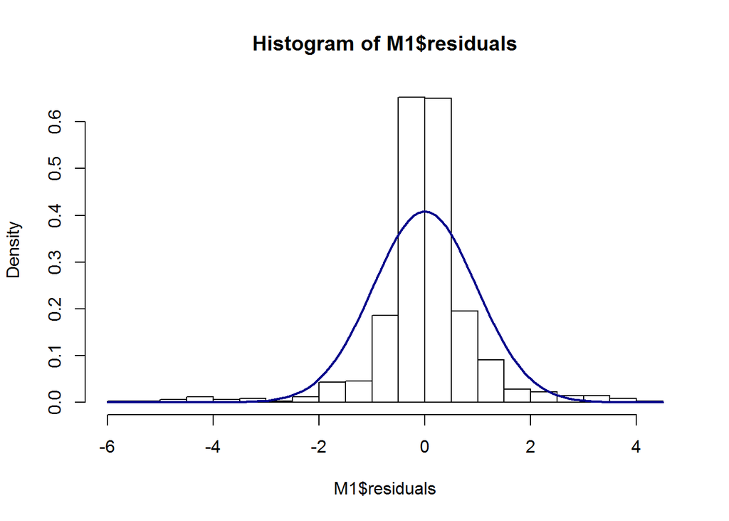

```r
hist(M1$residuals, breaks=30, prob=TRUE)
##overlay zero mean normal distribution
curve(dnorm(x, mean = 0, sd = sd(M1$residuals)), col = "darkblue", lwd = 2, add = TRUE)
```

By looking at the empirical distribution of the residuals, we see that the mean is approximately zero (in fact, we cannot reject that null hypothesis). This is a characteristic of the OLS process - that the residuals will have an average value of zero - there is no BIAS in the estimates. We are, ON AVERAGE, not overshooting or undershooting with our predictive model. However, if you force the regression line through the origin, then this may not be the case - the residuals may have a nonzero mean which results in a systematic bias, but there may be reasons to tradeoff some bias say, to reduce variance in generalizing to out-of-sample predictions on datapoints the model “hasn’t seen.”

```r
##looking at the residual behavior of the other models
summary(M2$residuals)
```

```
##     Min.  1st Qu.   Median     Mean  3rd Qu.     Max.
## -5.59798 -0.40387 -0.12542 -0.06932  0.24191  4.33306
```

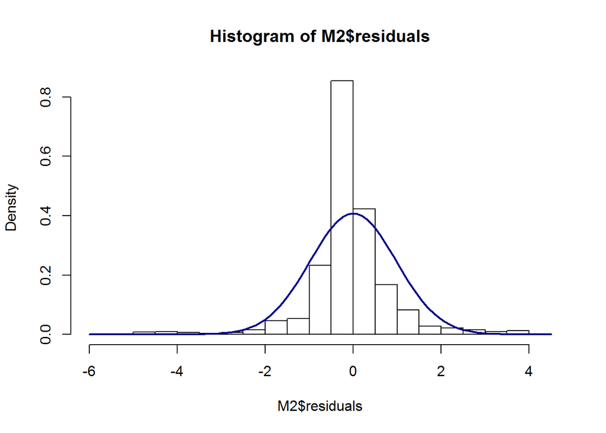

```r
hist(M2$residuals, breaks=30, prob=TRUE)
##overlay zero mean normal distribution
curve(dnorm(x, mean = 0, sd = sd(M2$residuals)), col = "darkblue", lwd = 2, add = TRUE)
```

```r
summary(M3$residuals)
```

```
##     Min.  1st Qu.   Median     Mean  3rd Qu.     Max.
## -4.93349 -0.42870 -0.13925 -0.07497  0.20498  4.53176
```

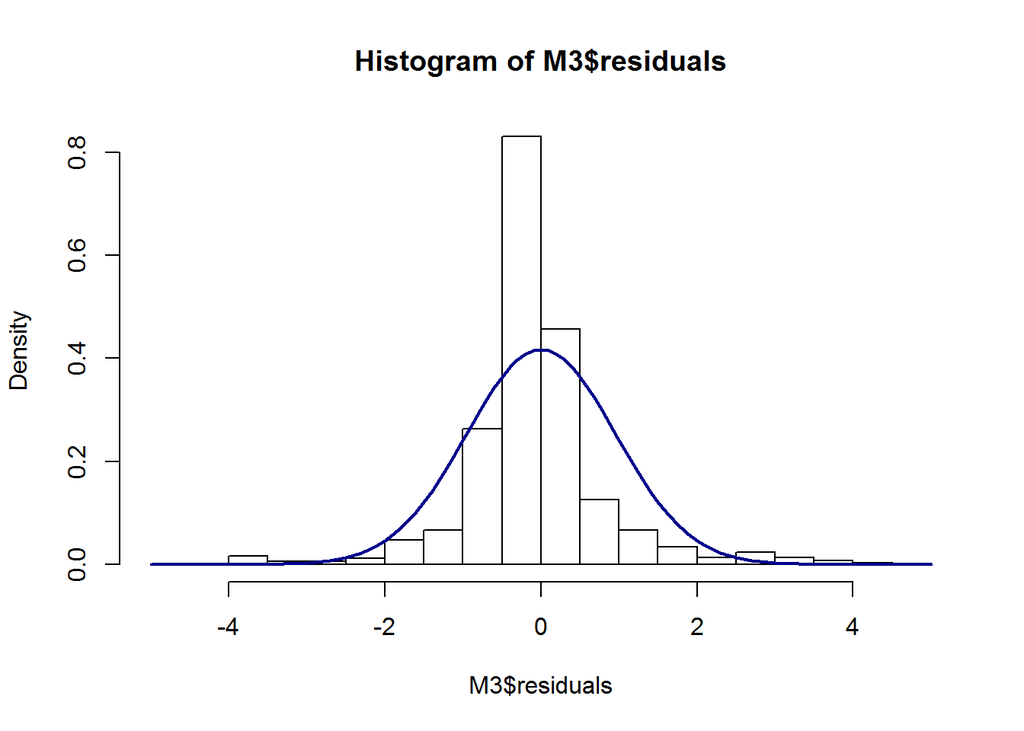

```r
hist(M3$residuals, breaks=30, prob=TRUE)
##overlay zero mean normal distribution
curve(dnorm(x, mean = 0, sd = sd(M3$residuals)), col = "darkblue", lwd = 2, add = TRUE)
```

```r
summary(M4$residuals)
```

```
##     Min.  1st Qu.   Median     Mean  3rd Qu.     Max.
## -4.97958 -0.42930 -0.13911 -0.07321  0.20958  4.57850
```

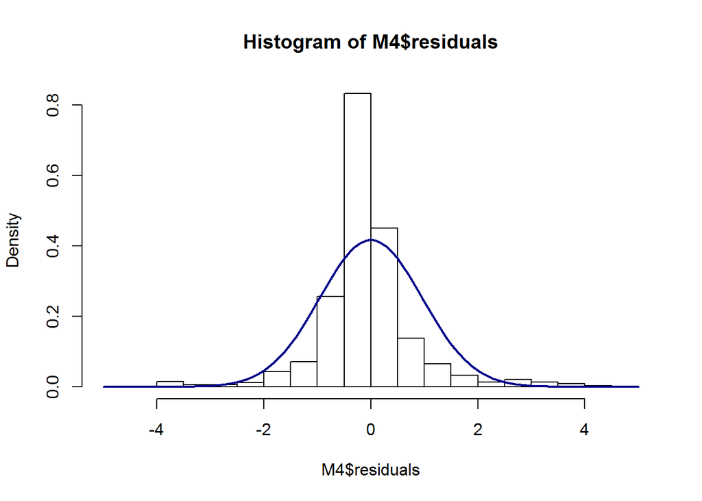

```r
hist(M4$residuals, breaks=30, prob=TRUE)
##overlay zero mean normal distribution
curve(dnorm(x, mean = 0, sd = sd(M4$residuals)), col = "darkblue", lwd = 2, add = TRUE)
```

```r
summary(M5$residuals)
```

```
##      Min.   1st Qu.    Median      Mean   3rd Qu.      Max.
## -4.405348 -0.316750  0.003033  0.011579  0.301796  3.809777
```

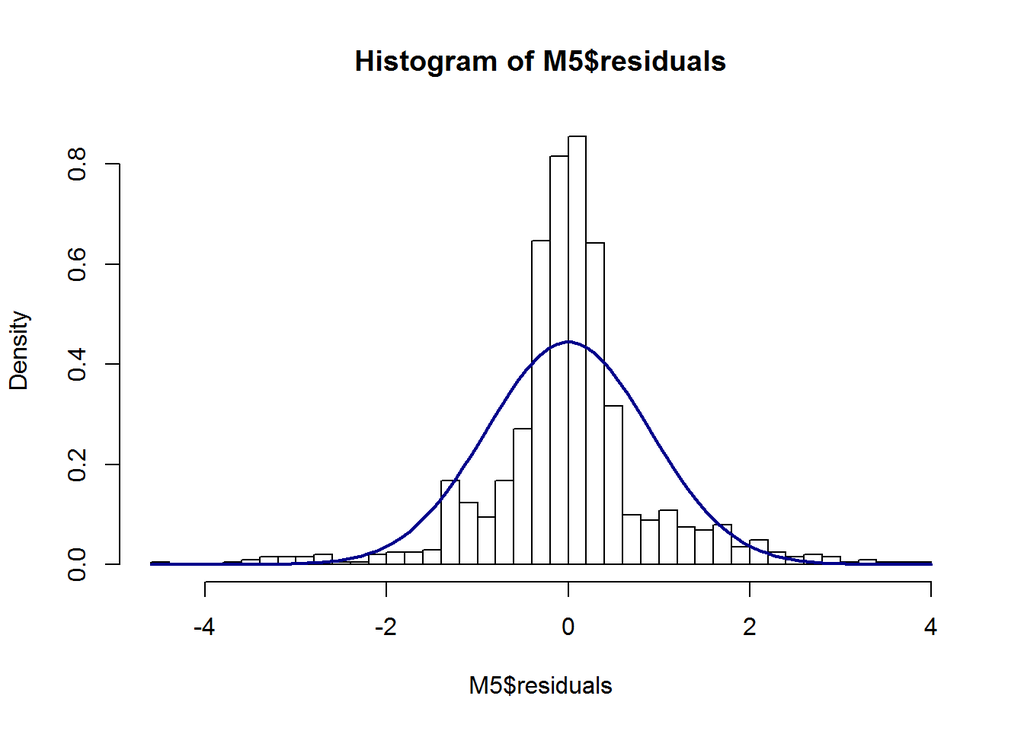

```r
hist(M5$residuals, breaks=30, prob=TRUE)
##overlay zero mean normal distribution
curve(dnorm(x, mean = 0, sd = sd(M5$residuals)), col = "darkblue", lwd = 2, add = TRUE)
```

In all of the other model iterations (M2-M5) where we forced the regression through the origin, the mean of the residual errors is not zero (not apparent from the histograms with normal density overlay), meaning we’ve accepted some bias in the estimation in order to improve the fit of the model (in accordance with physical principles).

### Problem 4

Again we go back to the CLEANED version of the NHIS data called NHIS_A.

```r
##part a)
M6<-lm(height~weight, NHIS_A)
summary(M6)
```

```
##
## Call:
## lm(formula = height ~ weight, data = NHIS_A)
##
## Residuals:
##      Min       1Q   Median       3Q      Max
## -12.4058  -2.3054   0.1687   2.3278   9.6427
##
## Coefficients:
##              Estimate Std. Error t value Pr(>|t|)
## (Intercept) 57.730873   0.237508  243.07   <2e-16 ***
## weight       0.052596   0.001331   39.53   <2e-16 ***
## ---
## Signif. codes:  0 '***' 0.001 '**' 0.01 '*' 0.05 '.' 0.1 ' ' 1
##
## Residual standard error: 3.346 on 4187 degrees of freedom
## Multiple R-squared:  0.2718, Adjusted R-squared:  0.2716
## F-statistic:  1562 on 1 and 4187 DF,  p-value: < 2.2e-16
```

```r
M7<-lm(height~0+weight, NHIS_A)
summary(M7)
```

```
##
## Call:
## lm(formula = height ~ 0 + weight, data = NHIS_A)
##
## Residuals:
##     Min      1Q  Median      3Q     Max
## -41.640  -4.654   4.550  12.286  27.173
##
## Coefficients:
##        Estimate Std. Error t value Pr(>|t|)
## weight 0.368272   0.001126   327.1   <2e-16 ***
## ---
## Signif. codes:  0 '***' 0.001 '**' 0.01 '*' 0.05 '.' 0.1 ' ' 1
##
## Residual standard error: 13.01 on 4188 degrees of freedom
## Multiple R-squared:  0.9623, Adjusted R-squared:  0.9623
## F-statistic: 1.07e+05 on 1 and 4188 DF,  p-value: < 2.2e-16
```

Note that the model that forces the regression through the origin actually does generate a much higher R-squared than the model with an intercept term. The tradeoff is that we will accept some bias (on average) if we go with the regression through the origin model (M7).

Next, we consider capturing nonlinearities in the features within the linear model framework:

```r
##part b)
M8<-lm(height~I(weight)+I(weight^2), NHIS_A)
summary(M8)
```

```
##
## Call:
## lm(formula = height ~ I(weight) + I(weight^2), data = NHIS_A)
##
## Residuals:
##      Min       1Q   Median       3Q      Max
## -11.4274  -2.3215   0.1931   2.3923   9.6411
##
## Coefficients:
##               Estimate Std. Error t value Pr(>|t|)
## (Intercept)  4.961e+01  9.040e-01  54.873   <2e-16 ***
## I(weight)    1.446e-01  9.977e-03  14.497   <2e-16 ***
## I(weight^2) -2.483e-04  2.668e-05  -9.307   <2e-16 ***
## ---
## Signif. codes:  0 '***' 0.001 '**' 0.01 '*' 0.05 '.' 0.1 ' ' 1
##
## Residual standard error: 3.313 on 4186 degrees of freedom
## Multiple R-squared:  0.2865, Adjusted R-squared:  0.2862
## F-statistic: 840.5 on 2 and 4186 DF,  p-value: < 2.2e-16
```

Note that the quadratic effect of weight on height is statistically significant at the .1% level. Adding the extra term also explains an additional 1.5% of the varaition in height relative to the model with the intercept and only linear feature of weight (M6).

```r
##part b) level-log model
M9<-lm(height~log(weight), NHIS_A)
summary(M9)
```

```
##
## Call:
## lm(formula = height ~ log(weight), data = NHIS_A)
##
## Residuals:
##      Min       1Q   Median       3Q      Max
## -11.9231  -2.3171   0.1077   2.3055   9.6168
##
## Coefficients:
##             Estimate Std. Error t value Pr(>|t|)
## (Intercept)  18.1691     1.1969   15.18   <2e-16 ***
## log(weight)   9.4870     0.2328   40.75   <2e-16 ***
## ---
## Signif. codes:  0 '***' 0.001 '**' 0.01 '*' 0.05 '.' 0.1 ' ' 1
##
## Residual standard error: 3.318 on 4187 degrees of freedom
## Multiple R-squared:  0.284,  Adjusted R-squared:  0.2838
## F-statistic:  1660 on 1 and 4187 DF,  p-value: < 2.2e-16
```

```r
##part c)  log-level model
M10<-lm(log(height)~weight, NHIS_A)
summary(M10)
```

```
##
## Call:
## lm(formula = log(height) ~ weight, data = NHIS_A)
##
## Residuals:
##       Min        1Q    Median        3Q       Max
## -0.190761 -0.034319  0.003575  0.035664  0.138877
##
## Coefficients:
##              Estimate Std. Error t value Pr(>|t|)
## (Intercept) 4.066e+00  3.550e-03 1145.17   <2e-16 ***
## weight      7.799e-04  1.989e-05   39.21   <2e-16 ***
## ---
## Signif. codes:  0 '***' 0.001 '**' 0.01 '*' 0.05 '.' 0.1 ' ' 1
##
## Residual standard error: 0.05002 on 4187 degrees of freedom
## Multiple R-squared:  0.2686, Adjusted R-squared:  0.2684
## F-statistic:  1538 on 1 and 4187 DF,  p-value: < 2.2e-16
```

```r
##part d)  log-log model
M11<-lm(log(height)~log(weight), NHIS_A)
summary(M11)
```

```
##
## Call:
## lm(formula = log(height) ~ log(weight), data = NHIS_A)
##
## Residuals:
##       Min        1Q    Median        3Q       Max
## -0.183727 -0.033943  0.003321  0.035779  0.138539
##
## Coefficients:
##             Estimate Std. Error t value Pr(>|t|)
## (Intercept) 3.477415   0.017878  194.51   <2e-16 ***
## log(weight) 0.140963   0.003478   40.53   <2e-16 ***
## ---
## Signif. codes:  0 '***' 0.001 '**' 0.01 '*' 0.05 '.' 0.1 ' ' 1
##
## Residual standard error: 0.04957 on 4187 degrees of freedom
## Multiple R-squared:  0.2818, Adjusted R-squared:  0.2816
## F-statistic:  1643 on 1 and 4187 DF,  p-value: < 2.2e-16
```

The log-log model configuration is convenient in that it gives a constant percentage effect interpretation (rather than a constant unit effect) and is units free. In this case the coefficient on the log(weight) term can be interpreted as follows: a 1% increase in the weight of a person tends to translate in a 0.14% increase in the height of that person.

```r
##part e)
M12<-lm(educ~SLEEP, NHIS_A)  ##level-level
summary(M12)
```

```
##
## Call:
## lm(formula = educ ~ SLEEP, data = NHIS_A)
##
## Residuals:
##      Min       1Q   Median       3Q      Max
## -13.5936  -1.4672  -0.4672   2.5328   7.7855
##
## Coefficients:
##             Estimate Std. Error t value Pr(>|t|)
## (Intercept) 14.35174    0.27746  51.725  < 2e-16 ***
## SLEEP       -0.12636    0.03865  -3.269  0.00109 **
## ---
## Signif. codes:  0 '***' 0.001 '**' 0.01 '*' 0.05 '.' 0.1 ' ' 1
##
## Residual standard error: 3.044 on 4187 degrees of freedom
## Multiple R-squared:  0.002546,   Adjusted R-squared:  0.002307
## F-statistic: 10.69 on 1 and 4187 DF,  p-value: 0.001088
```

```r
M13<-lm(educ~log(SLEEP), NHIS_A)  ##level-log
summary(M13)
```

```
##
## Call:
## lm(formula = educ ~ log(SLEEP), data = NHIS_A)
##
## Residuals:
##     Min      1Q  Median      3Q     Max
## -13.552  -1.455  -0.455   2.545   7.703
##
## Coefficients:
##             Estimate Std. Error t value Pr(>|t|)
## (Intercept)  14.6759     0.5178  28.344   <2e-16 ***
## log(SLEEP)   -0.6274     0.2656  -2.362   0.0182 *
## ---
## Signif. codes:  0 '***' 0.001 '**' 0.01 '*' 0.05 '.' 0.1 ' ' 1
##
## Residual standard error: 3.045 on 4187 degrees of freedom
## Multiple R-squared:  0.001331,   Adjusted R-squared:  0.001092
## F-statistic:  5.58 on 1 and 4187 DF,  p-value: 0.01821
```

```r
##M14<-lm(log(educ)~SLEEP, NHIS_A)  ##log-level
##summary(M14)

##M15<-lm(log(educ)~log(SLEEP), NHIS_A)  ##log-log
##summary(M15)
```

```r
##part f)
M16<-lm(educ[NHIS_A$SEX==1]~SLEEP[NHIS_A$SEX==1], NHIS_A)  ##level-level
summary(M16)
```

```
##
## Call:
## lm(formula = educ[NHIS_A$SEX == 1] ~ SLEEP[NHIS_A$SEX == 1],
##     data = NHIS_A)
##
## Residuals:
##      Min       1Q   Median       3Q      Max
## -13.5101  -1.5101  -0.5101   2.4899   7.8715
##
## Coefficients:
##                        Estimate Std. Error t value Pr(>|t|)
## (Intercept)            14.84565    0.43463   34.16  < 2e-16 ***
## SLEEP[NHIS_A$SEX == 1] -0.19079    0.06116   -3.12  0.00184 **
## ---
## Signif. codes:  0 '***' 0.001 '**' 0.01 '*' 0.05 '.' 0.1 ' ' 1
##
## Residual standard error: 3.057 on 1932 degrees of freedom
## Multiple R-squared:  0.005012,   Adjusted R-squared:  0.004497
## F-statistic: 9.732 on 1 and 1932 DF,  p-value: 0.001838
```

```r
M17<-lm(educ[NHIS_A$SEX==2]~SLEEP[NHIS_A$SEX==2], NHIS_A)  ##level-level
summary(M17)
```

```
##
## Call:
## lm(formula = educ[NHIS_A$SEX == 2] ~ SLEEP[NHIS_A$SEX == 2],
##     data = NHIS_A)
##
## Residuals:
##      Min       1Q   Median       3Q      Max
## -13.5059  -1.4256  -0.4256   2.5744   7.7350
##
## Coefficients:
##                        Estimate Std. Error t value Pr(>|t|)
## (Intercept)            13.98761    0.36133  38.712   <2e-16 ***
## SLEEP[NHIS_A$SEX == 2] -0.08029    0.04991  -1.609    0.108
## ---
## Signif. codes:  0 '***' 0.001 '**' 0.01 '*' 0.05 '.' 0.1 ' ' 1
##
## Residual standard error: 3.032 on 2253 degrees of freedom
## Multiple R-squared:  0.001147,   Adjusted R-squared:  0.0007038
## F-statistic: 2.588 on 1 and 2253 DF,  p-value: 0.1078
```

```r
M18<-lm(educ[NHIS_A$SEX==1]~log(SLEEP[NHIS_A$SEX==1]), NHIS_A)  ##level-log
summary(M18)
```

```
##
## Call:
## lm(formula = educ[NHIS_A$SEX == 1] ~ log(SLEEP[NHIS_A$SEX ==
##     1]), data = NHIS_A)
##
## Residuals:
##      Min       1Q   Median       3Q      Max
## -13.4963  -1.4963  -0.4963   2.5037   7.7388
##
## Coefficients:
##                             Estimate Std. Error t value Pr(>|t|)
## (Intercept)                  15.3169     0.7949  19.268   <2e-16 ***
## log(SLEEP[NHIS_A$SEX == 1])  -0.9356     0.4094  -2.285   0.0224 *
## ---
## Signif. codes:  0 '***' 0.001 '**' 0.01 '*' 0.05 '.' 0.1 ' ' 1
##
## Residual standard error: 3.061 on 1932 degrees of freedom
## Multiple R-squared:  0.002696,   Adjusted R-squared:  0.00218
## F-statistic: 5.223 on 1 and 1932 DF,  p-value: 0.0224
```

```r
M19<-lm(educ[NHIS_A$SEX==2]~log(SLEEP[NHIS_A$SEX==2]), NHIS_A)  ##level-log
summary(M19)
```

```
##
## Call:
## lm(formula = educ[NHIS_A$SEX == 2] ~ log(SLEEP[NHIS_A$SEX ==
##     2]), data = NHIS_A)
##
## Residuals:
##      Min       1Q   Median       3Q      Max
## -13.4752  -1.4161  -0.4161   2.5839   7.6803
##
## Coefficients:
##                             Estimate Std. Error t value Pr(>|t|)
## (Intercept)                  14.1628     0.6831  20.733   <2e-16 ***
## log(SLEEP[NHIS_A$SEX == 2])  -0.3837     0.3492  -1.099    0.272
## ---
## Signif. codes:  0 '***' 0.001 '**' 0.01 '*' 0.05 '.' 0.1 ' ' 1
##
## Residual standard error: 3.032 on 2253 degrees of freedom
## Multiple R-squared:  0.0005356,  Adjusted R-squared:  9.198e-05
## F-statistic: 1.207 on 1 and 2253 DF,  p-value: 0.272
```

After separating the data out by male and female, we can generate the models over each subset of data. Loking at the summary results, it seems that the “night owl effect” is still present for the males in the sample (SEX=1) but the result seems to lose statistical significance when we look at the females in the sample (SEX=2).

### Problem 5:

Following the instructions from the problem, we run (approximately) the code suggested below:

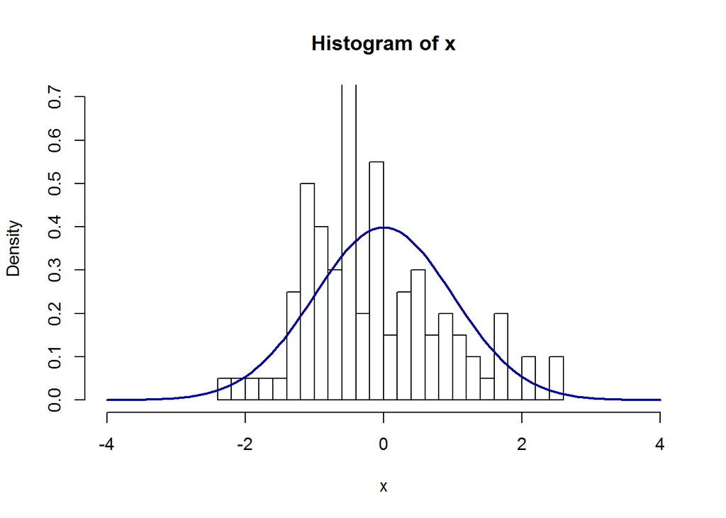

```r
##Part a
x<-rnorm(n=100, mean=0, sd=1)
##Part b)
hist(x, breaks = 30, prob = TRUE, xlim=c(-4,4), ylim=c(0,.7))
curve(dnorm(x, mean = 0, sd = 1), col = "darkblue", lwd = 2, add = TRUE)
```

Note that the empirical distribution (the blocky histogram) isn’t a perfect fit to the normal distribution (the population function from which the data was sampled/drawn). As we increase the number of data points sampled, the quality of the fit to the normal distribution improves, consistent with the LLN:

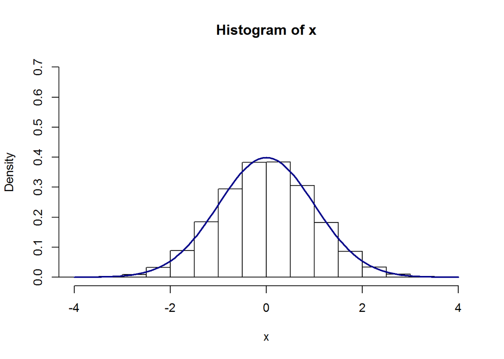

```r
##Part c
x<-rnorm(n=100000, mean=0, sd=1)
hist(x, breaks = 30, prob = TRUE, xlim=c(-4,4), ylim=c(0,.7))
curve(dnorm(x, mean = 0, sd = 1), col = "darkblue", lwd = 2, add = TRUE)
```

### Problem 6

Part a) essentially asks us to compute the following probability using the cumulative distribution function (CDF) for the standard normal distribution: F(1)-F(-1)

```r
##Part a
pnorm(1,0,1)-pnorm(-1,0,1)
```

```
## [1] 0.6826895
```

Similarly,

```r
##Part b
pnorm(2,0,1)-pnorm(-2,0,1)
```

```
## [1] 0.9544997
```

Likewise,

```r
##Part c
pnorm(3,0,1)-pnorm(-3,0,1)
```

```
## [1] 0.9973002
```

Part d): Observing the probabilities above should be consistent with Chebychev’s rule - that 68% of the data lie within one standard deviation of the mean, 95% within two, and 99.7% within three… Part e) essentially asks us to compute 1-F(2.5) for the standard normal distribution for only a single (right side) tail:

```r
##Part e
1-pnorm(2.5,0,1)
```

```
## [1] 0.006209665
```

Similarly, part f) asks for the right tail probability, but also adds the left tail probability (since it asks about values more extreme in absolute value implying that they could be positive or negative):

```r
##Part f
1-pnorm(1.5,0,1)+pnorm(-1.5,0,1)
```

```
## [1] 0.1336144
```

```r
##OR, by symmetry of the distriubtion, we could have computed the size of one tail and doubled it
```

The final part of problem 2 (part g) essentially asks us to consider the conditional probability: P(X between 2 and 3| X bigger than 1)=P(X between 2 and 3 intersect X bigger than 1)/P(X bigger than 1) by Baye’s. Note that if x is between two it must also be bigger than one so that the numerator is the same as P(X between 2 and 3), which is F(3)-F(2) using the standard normal’s CDF. The denominator of the expression, P(X bigger than 1)is just the compliment of F(1). Thus, the probability that we need to compute is (F(3)-F(2))/(1-F(1)):

```r
##Part g
(pnorm(3,0,1)-pnorm(2,0,1))/(1-pnorm(1,0,1))
```

```
## [1] 0.1348851
```

### Problem 7

This problem is essentially an empirical verification of the CLT. Below, we sample 10000 draws from the uniform distribution (on the interval [0,1]) and plot the empirical distribution:

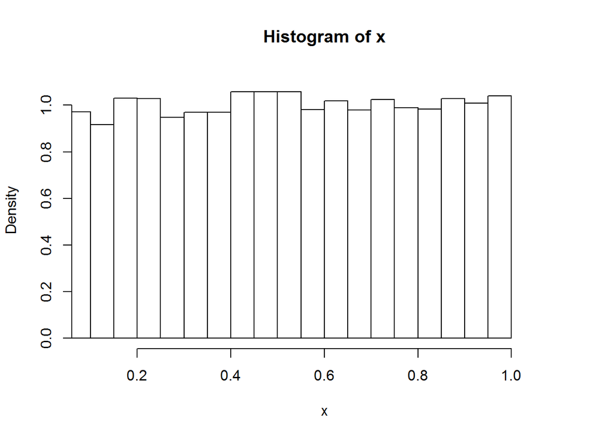

```r
##Part a
x<-runif(10000,0,1)
hist(x, breaks = 30, prob = TRUE, xlim=c(--.1,1.1), ylim=c(0,1.1))
```

Note that it is approximately flat (as we expect for the uniform distribution). To empirically “verify” the CLT, we will sample 30 observations, compute the sample mean, and repeat this process 1000 times so that we have 1000 sample means estimated (each slightly different since the data being drawn each time isn’t the same at each repitition of the 30 draws of data). We use a for loop to run the “experiment” over 1000 repetitions without having to do so manually:

```r
reps<-1000
draws<- 30
rv <- NULL  ##place holder for the variable
normed <- NULL  ##place holder for the variable
b<-1  ##assigns endpoint to the uniform distribution
a<-0  ##assigns endpoint to the uniform distribution
mu<-1/2*(b+a) ##this is the actual population mean for the uniform distriubtion (the center of the rectangle)

for (i in 1:reps){  ##this for loop does the same thing indexing over the values of the repetitions
  rv<-runif(draws, 0, 1)  ##draw a sample for this repetition
  xbar<-mean(rv)  ##computes the sample mean for this particular set of draws
  se<-((1/12)*(b-a)^2)^.5/sqrt(draws)  ##computes the small sample standard error
  normed[i]<-(xbar-mu)/se  ##normalizes the sample data and stores the average for this repetition of draws in a vector that will be added to at each repetition with the new sample mean
}
```

Now we will plot the 1000 sample means that were generated by sampling from a uniform flat) distribution:

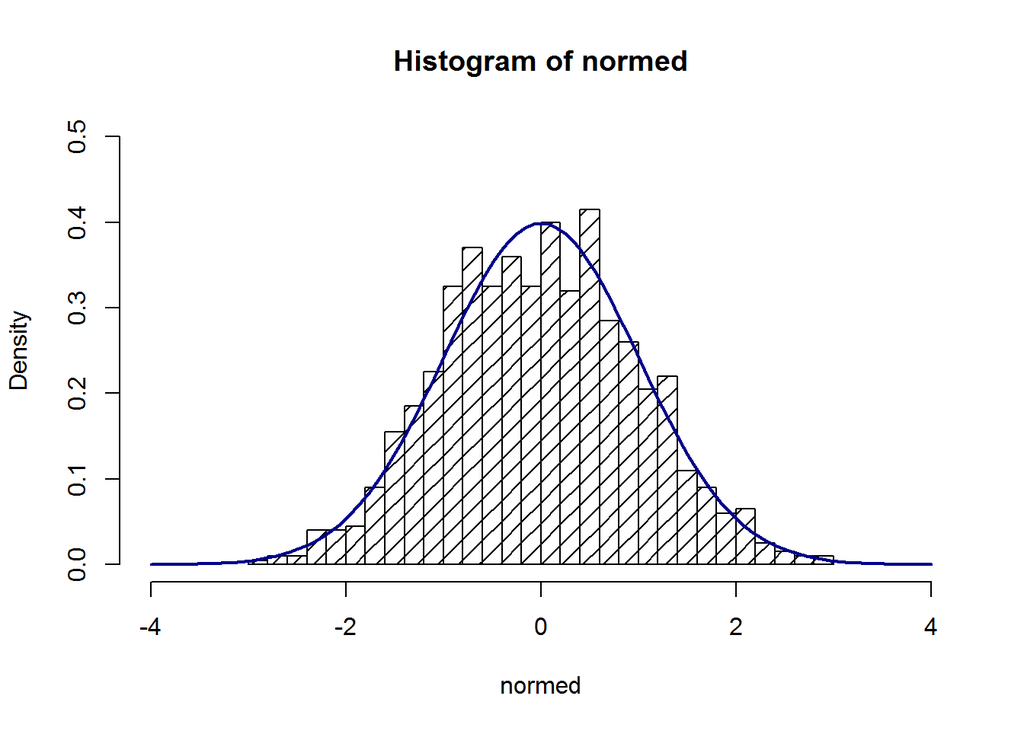

```r
hist(normed, density = 10, breaks = 30, prob = TRUE, ylim = c(0,.5), xlim = c(-4,4))
curve(dnorm(x, mean = 0, sd = 1), col = "darkblue", lwd = 2, add = TRUE)
```

Note that the sample means, which were calculated as averages of draws from a flat distribution, are approximately normally distributed despite the underlying distribution the data was being sampled from was uniformly generated. This tells us that the normal distribution is widely applicable to a variety of problems in statistics - the CLT essentially implies that the assumption of normality may be reasonable in many cases.

### Problem 8

```r
##part a

##sample the error term
n=2 ##sample size
sigma=1  ##error standard deviation
e<-rnorm(n,0,sigma)  ##draws normally distributed error
B_0=5  ##population intercept term
B_1=2  ##population slope term
```

Next, we synthesize the x-variable data per the instructions. Using the synthesized x-data and simulated errors, we can construct synthetic y-variable data per the DGP and create a dataframe:

```r
##part b

x_synth<-runif(n,0,10)  ##generates synthetic x (input) data
y_synth<-B_0+B_1*x_synth+e  ##generates simulated y values from the DGP
data<-cbind(y_synth, x_synth)  ##bind the columns of the y and x data together
df1<-as.data.frame(data)  ##convert to dataframe object
##View(df1)  ##view newly created dataframe
```

Next, we plot the synthetic data against the DGP and the best linear hypothesis from that data:

```r
##part c-e

plot(x_synth, y_synth)  ##plot the data
abline(B_0,B_1, col='red')  ##add the population regression line (DGP)
hyp<-lm(y_synth~x_synth, df1)  ##estimate linear model
summary(hyp)
```

```
##
## Call:
## lm(formula = y_synth ~ x_synth, data = df1)
##
## Residuals:
## ALL 2 residuals are 0: no residual degrees of freedom!
##
## Coefficients:
##             Estimate Std. Error t value Pr(>|t|)
## (Intercept)    4.084         NA      NA       NA
## x_synth        2.104         NA      NA       NA
##
## Residual standard error: NaN on 0 degrees of freedom
## Multiple R-squared:      1,  Adjusted R-squared:    NaN
## F-statistic:   NaN on 1 and 0 DF,  p-value: NA
```

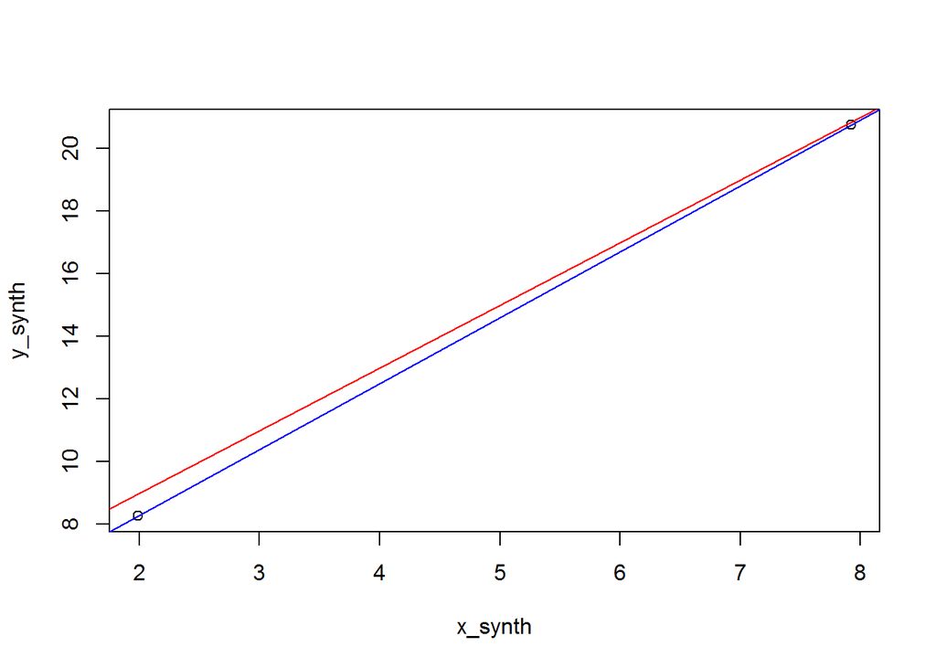

```r
abline(hyp$coefficients[1],hyp$coefficients[2], col='blue')  ##plots best linear hypothesis given the sample of data
```

Note that the in-sample error is zero (sum of squared residuals is zero and R-squared is 1) and that the linear hypothesis has perfectly fit the two data points that we’ve sampled from the DGP. However, if we were to sample to different points from the DGP (the red line), the hypothesis based on our current data wouldn’t be correct and we would face a signinficant out-of-sample error. First, we compute the in-sample error:

```r
##part f

E_IN<-sqrt(sum(hyp$residuals^2/n))
E_IN
```

```
## [1] 0
```

To compute the out-of-sample error, we must measure the squared deviation of the hypothesis from the DGP (distance from the blue line and the red line at each value of the x-variable sampled):

```r
#part g-h
y_DGP=B_0+B_1*x_synth
E_OUT<-sqrt(sum((hyp$fitted.values-y_DGP)^2/n))
E_OUT
```

```
## [1] 0.5067299
```

If we repeat the same experiment but increase the sample size, we should see two things: first, the linear hypothesis will not be able to perfectly fit more than two points (unless the points sampled all randomly happen to fall in line, and this happens with zero probability). As a consequence, the in-sample error (E_IN) will increase as we sample more points for the same complexity of hypothesis (linear with a single feature). The second thing we should see happen is an improvement with out out-of-sample error from an increased sample size since our estimates of the population parameters will have smaller standard errors:

```r
# part i
n=10 ##sample size
e<-rnorm(n,0,sigma)  ##draws normally distributed error
x_synth<-runif(n,0,10)  ##generates synthetic x (input) data
y_synth<-B_0+B_1*x_synth+e  ##generates simulated y values from the DGP
data<-cbind(y_synth, x_synth)  ##bind the columns of the y and x data together
df1<-as.data.frame(data)
plot(x_synth, y_synth)  ##plot the data
abline(B_0,B_1, col='red')  ##add the population regression line (DGP)
hyp<-lm(y_synth~x_synth, df1)  ##estimate linear model
summary(hyp)
```

```
##
## Call:
## lm(formula = y_synth ~ x_synth, data = df1)
##
## Residuals:
##     Min      1Q  Median      3Q     Max
## -1.3993 -0.4397  0.1939  0.3031  1.0290
##
## Coefficients:
##             Estimate Std. Error t value Pr(>|t|)
## (Intercept)  5.42385    0.56539   9.593 1.16e-05 ***
## x_synth      1.92240    0.08381  22.938 1.38e-08 ***
## ---
## Signif. codes:  0 '***' 0.001 '**' 0.01 '*' 0.05 '.' 0.1 ' ' 1
##
## Residual standard error: 0.7793 on 8 degrees of freedom
## Multiple R-squared:  0.985,  Adjusted R-squared:  0.9832
## F-statistic: 526.2 on 1 and 8 DF,  p-value: 1.384e-08
```

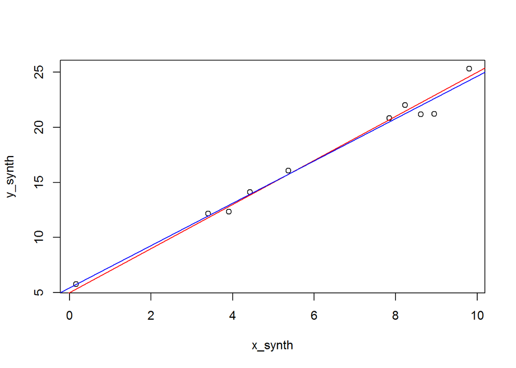

```r
abline(hyp$coefficients[1],hyp$coefficients[2], col='blue')  ##plots best linear hypothesis given the sample of data
```

Note that when we sample 10 points, the coefficient estimates are much closer to the population parameters than they were with only two points. As we anticipated, the R-squared has fallen since the in-sample fit is now not as good for the linear model on 10 points. We can also compute the in-sample and out-of-sample errors again:

```r
E_IN<-sqrt(sum(hyp$residuals^2/n))
E_IN
```

```
## [1] 0.6970151
```

```r
y_DGP=B_0+B_1*x_synth
E_OUT<-sqrt(sum((hyp$fitted.values-y_DGP)^2/n))
E_OUT
```

```
## [1] 0.2330554
```

As we suspected, the in-sample error has increased, but the out-of-sample error has decreased! We can see more of the same as we increase the sample size further:

```r
n=100 ##sample size
e<-rnorm(n,0,sigma)  ##draws normally distributed error
x_synth<-runif(n,0,10)  ##generates synthetic x (input) data
y_synth<-B_0+B_1*x_synth+e  ##generates simulated y values from the DGP
data<-cbind(y_synth, x_synth)  ##bind the columns of the y and x data together
df1<-as.data.frame(data)
plot(x_synth, y_synth)  ##plot the data
abline(B_0,B_1, col='red')  ##add the population regression line (DGP)
hyp<-lm(y_synth~x_synth, df1)  ##estimate linear model
summary(hyp)
```

```
##
## Call:
## lm(formula = y_synth ~ x_synth, data = df1)
##
## Residuals:
##      Min       1Q   Median       3Q      Max
## -2.45053 -0.61085 -0.08965  0.55712  2.06631
##
## Coefficients:
##             Estimate Std. Error t value Pr(>|t|)
## (Intercept)  5.03879    0.17202   29.29   <2e-16 ***
## x_synth      2.00359    0.03159   63.43   <2e-16 ***
## ---
## Signif. codes:  0 '***' 0.001 '**' 0.01 '*' 0.05 '.' 0.1 ' ' 1
##
## Residual standard error: 0.8703 on 98 degrees of freedom
## Multiple R-squared:  0.9762, Adjusted R-squared:  0.976
## F-statistic:  4024 on 1 and 98 DF,  p-value: < 2.2e-16
```

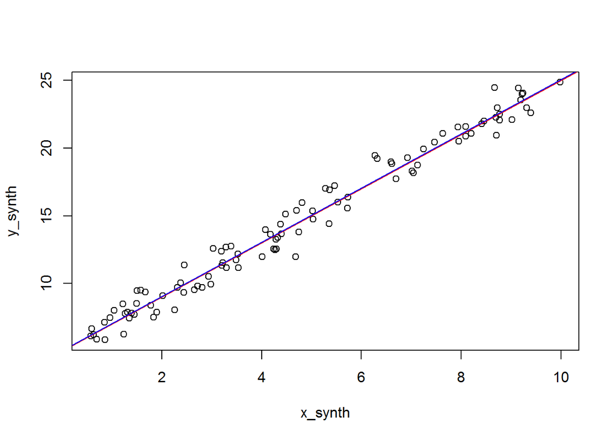

```r
abline(hyp$coefficients[1],hyp$coefficients[2], col='blue')  ##plots best linear hypothesis given the sample of data
```

```r
E_IN<-sqrt(sum(hyp$residuals^2/n))
E_IN
```

```
## [1] 0.8615488
```

```r
y_DGP=B_0+B_1*x_synth
E_OUT<-sqrt(sum((hyp$fitted.values-y_DGP)^2/n))
E_OUT
```

```
## [1] 0.05653478
```

With a sample of 100 points from the DGP, the in-sample error increased while the out-of-sample error shrinks as we suspected. Next, we repeat the experiment for 1000 data points to find the same thing:

```r
n=1000 ##sample size
e<-rnorm(n,0,sigma)  ##draws normally distributed error
x_synth<-runif(n,0,10)  ##generates synthetic x (input) data
y_synth<-B_0+B_1*x_synth+e  ##generates simulated y values from the DGP
data<-cbind(y_synth, x_synth)  ##bind the columns of the y and x data together
df1<-as.data.frame(data)
plot(x_synth, y_synth)  ##plot the data
abline(B_0,B_1, col='red')  ##add the population regression line (DGP)
hyp<-lm(y_synth~x_synth, df1)  ##estimate linear model
summary(hyp)
```

```
##
## Call:
## lm(formula = y_synth ~ x_synth, data = df1)
##
## Residuals:
##     Min      1Q  Median      3Q     Max
## -3.2270 -0.6932 -0.0066  0.6794  3.1425
##
## Coefficients:
##             Estimate Std. Error t value Pr(>|t|)
## (Intercept)  4.97868    0.06386   77.97   <2e-16 ***
## x_synth      2.00006    0.01094  182.79   <2e-16 ***
## ---
## Signif. codes:  0 '***' 0.001 '**' 0.01 '*' 0.05 '.' 0.1 ' ' 1
##
## Residual standard error: 1.017 on 998 degrees of freedom
## Multiple R-squared:  0.971,  Adjusted R-squared:  0.971
## F-statistic: 3.341e+04 on 1 and 998 DF,  p-value: < 2.2e-16
```

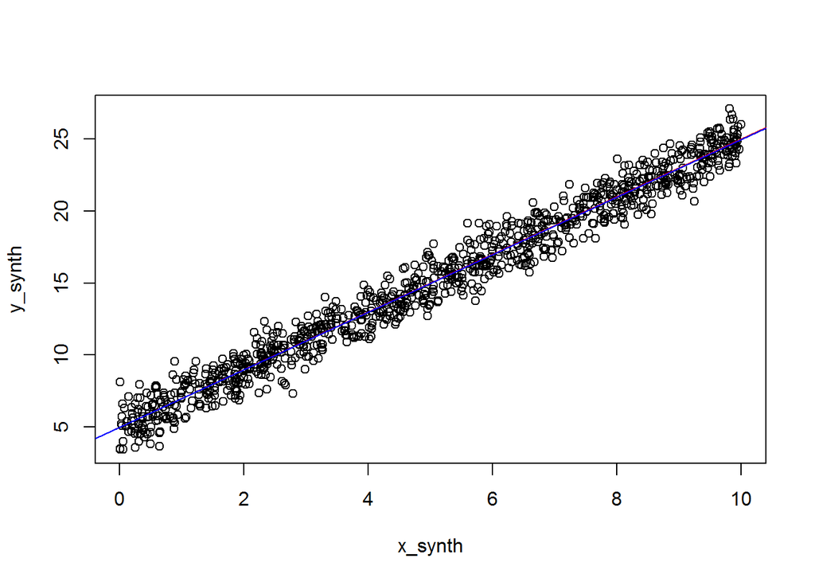

```r
abline(hyp$coefficients[1],hyp$coefficients[2], col='blue')  ##plots best linear hypothesis given the sample of data
```

```r
E_IN<-sqrt(sum(hyp$residuals^2/n))
E_IN
```

```
## [1] 1.015686
```

```r
y_DGP=B_0+B_1*x_synth
E_OUT<-sqrt(sum((hyp$fitted.values-y_DGP)^2/n))
E_OUT
```

```
## [1] 0.02099483
```

### Problem 9

First, we generate the synthetic data per the parameters of the problem

```r
##generate synthetic data
n1=100
n2=100
d1<-rnorm(n1,2, 15) ##data from group 1
d2<-runif(n2,5, 15)  ##data from group 2
```

Let’s look at histogram plots where we’ve locked the axis parameters to see how these groups are related:

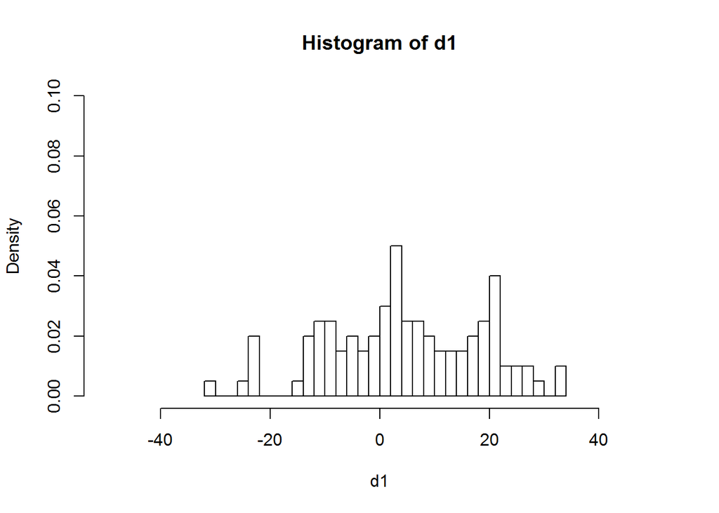

```r
hist(d1, breaks = 30, prob = TRUE, xlim=c(-50,50), ylim=c(0,.1))
```

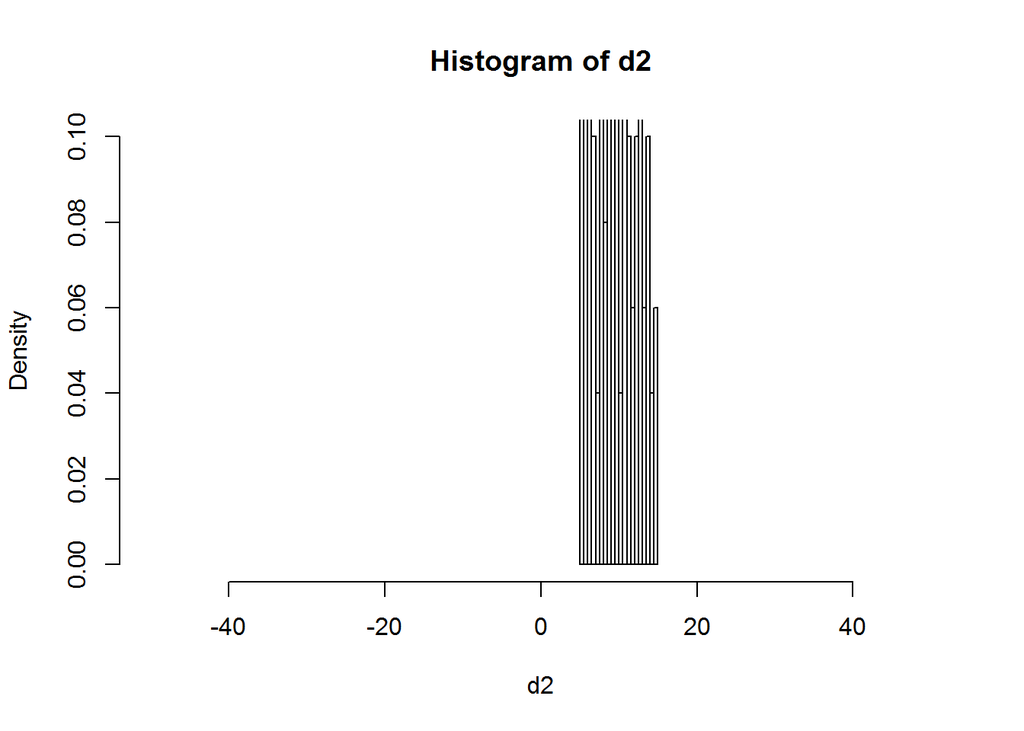

```r
hist(d2, breaks = 30, prob = TRUE, xlim=c(-50,50), ylim=c(0,.1))
```

Next, we construct our data frame by stacking the vectors on top of each other to form a single column of variable data. We also create a column for a dummy variable identifying an observaton from the first group (1) or the second group (0):

```r
Z1<-as.matrix(c(d1,d2))  ##stack vectors
ones_vec<-rep(1, n1)  ##creates dummy variables for group 1
zeros_vec<-rep(0,n2)  ##creates dummy variables for group 2
Z2<-as.matrix(c(ones_vec, zeros_vec))  ##stacks vectors
##View(Z2)
df2<-as.data.frame(cbind(Z1, Z2))  ##creates data frame
##View(df2)
colnames(df2)<-c("var1", "dummy")  ##renames columns
##to rename rows, use rownames()
```

Next, we construct the plot, adding the elements of interest per the instructions:

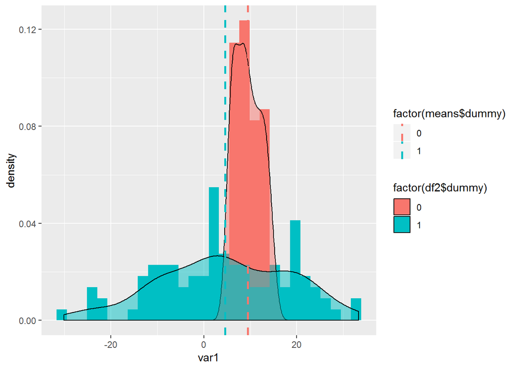

```r
###parts a-c
means <- ddply(df2, "dummy", summarise, meanvar1=mean(var1))
plot_e<-ggplot(df2,aes(x=var1, fill = factor(df2$dummy))) +
  geom_histogram(aes(y=..density..), position = "identity") +
  geom_density(alpha = .5) +
  geom_vline(data=means, aes(xintercept=meanvar1, col=factor(means$dummy)), linetype="dashed", size=1)  ##adds vertical line at the mean of each group
plot_e
```